# GIS with R: examples from Slovakia

July 2019

## Geospatial analysis. Why are we doing this?

1. Most of our data we collect are a recording of some phenomena that happened at a specific place and time.
2. Good visualisations and methods from spatio-temporal analysis field can help us understand our data.

## This tutorial

1. Spatial data and coordinate systems.
2. Introduction to `sf` package.
3. Visualisations.
4. Example of analysis: spatial autocorrelation.

## Extra resources

Recommended textbooks:

- **Geocomputation with R**. Available [online](https://geocompr.robinlovelace.net/).
- Gelfand, Alan E., ed. 2010. **Handbook of Spatial Statistics**. Chapman & Hall/CRC Handbooks of Modern Statistical Methods. Boca Raton: CRC Press.
- Wikle, Christopher K., Andrew Zammit-Mangion, and Noel Cressie. 2019. **Spatio-Temporal Statistics with R**. 1st ed. Boca Raton, Florida : CRC Press, [2019]: Chapman and Hall/CRC. https://doi.org/10.1201/9781351769723.

Other sources:

- r-spatial.org is a portal for people interested in spatial modelling.
- Packages like `sf`, `sp` tend to be well-documented, and with worked examples.

## Spatial data

- Data frames, but now each row has a geometry associated with it (usually a point or an area).
- We need to be careful with the coordinate systems:
  - If working at macro scale (at world level), we need to take into account curvature of the Earth.
  - We stick to coordinate systems where we can work with Euclidean geometry.
  - The cadaster office in Slovakia uses **krovak** system, which is the legally binding coordinate system (coded as `EPSG:5513`).
  - This [website](https://epsg.io/5513) is useful for reading off the coordinates for a particular point.

## Obtaining geometry (map) files

- The map files come in different formats. One of the most common ones are shapefiles (`.shp`), geodatabase (`.gdb`), geopackage (`.gpk`), geoJSON (`.geojson`).
- This [page](https://www.geoportal.sk/sk/zbgis_smd/na-stiahnutie/) in the geoportal.sk has the necessary files in different formats. We stick to the shapefiles (`.shp`) format. The portal allows downloading the maps at different resolutions. In this guide, we will be working with the most precise one, which is referred to as ‘Základná úroveň/ ZBGIS - Administratívne hranice’.

## `sf` package

Install the package using:

```r
install.packages('sf')
```

```r
library('sf')
```

## `st_read()` to load maps

```
st_read(dsn, layer)
```

- `dsn`: file name of the map file.
- `layer`: certain file formats allow saving multiple layers, we will work with single layer files (it does not mean we can’t have multiple indicators/statistic for each location).

Load the map of Slovakia at the municipality level:

```r
mapa.obec.sf <- st_read(dsn = file.path(getwd(),
                                        'maps',
                                        'ah_shp_0',
                                        'obec_0.shp'))
```

## Inspecting the map object - coordinates

To see what coordinate system it uses, `st_crs()` function can be used:

```r
st_crs(mapa.obec.sf)
```

```
## Coordinate Reference System:
##   No EPSG code
##   proj4string: "+proj=krovak +lat_0=49.5 +lon_0=24.83333333333333 +alpha=30.28813975277778 +k=0.9999 +x_0=0 +y_0=0 +ellps=bessel +units=m +no_defs"
```

Due to the missing code, we do a transformation to the official code using `st_transform()` function.

```r
crsCodeSkCadastreOffice <- 5513  # save the cadastre CRS to a constant
mapa.obec.sf <- st_transform(x = mapa.obec.sf,
                             crs = crsCodeSkCadastreOffice)
st_crs(mapa.obec.sf)
```

## Inspecting the map object - data

```r
summary(mapa.obec.sf)
```

```
##       DOW                  AUT         ACH         SOI       FACC           IDN4              NM4            IDN3
##  Min.   :2019-04-30   Min.   :1   Min.   :1   Min.   :9   FA004:2927   Min.   :500011   Lúčka   :   4   Min.   :101.0
##  1st Qu.:2019-04-30   1st Qu.:1   1st Qu.:1   1st Qu.:9                1st Qu.:508989   Porúbka :   4   1st Qu.:402.0
##  Median :2019-04-30   Median :1   Median :1   Median :9                Median :518204   Dúbrava :   3   Median :606.0
##  Mean   :2019-04-30   Mean   :1   Mean   :1   Mean   :9                Mean   :521206   Lúčky   :   3   Mean   :547.7
##  3rd Qu.:2019-04-30   3rd Qu.:1   3rd Qu.:1   3rd Qu.:9                3rd Qu.:526138   Petrovce:   3   3rd Qu.:708.0
##  Max.   :2019-04-30   Max.   :1   Max.   :1   Max.   :9                Max.   :599972   Píla    :   3   Max.   :811.0
##                                                                                         (Other) :2907
##               NM3            IDN2                    NM2          VYMERA            Shape_Leng       Shape_Area
##  Košice - okolie: 114   Min.   :1.000   Prešovský      :665   Min.   :   361255   Min.   :  3211   Min.   :   354208
##  Rimavská Sobota: 107   1st Qu.:4.000   Banskobystrický:516   1st Qu.:  7207245   1st Qu.: 14031   1st Qu.:  7207035
##  Prešov         :  91   Median :6.000   Košický        :461   Median : 11655767   Median : 18582   Median : 11647728
##  Levice         :  89   Mean   :5.415   Nitriansky     :354   Mean   : 16752332   Mean   : 21367   Mean   : 16747701
##  Bardejov       :  86   3rd Qu.:7.000   Žilinský       :315   3rd Qu.: 19769322   3rd Qu.: 25503   3rd Qu.: 19794868
##  Trebišov       :  82   Max.   :8.000   Trenčiansky    :276   Max.   :359784254   Max.   :204284   Max.   :359936992
##  (Other)        :2358                   (Other)        :340
##           geometry
##  MULTIPOLYGON :2927
##  epsg:5513    :   0
##  +proj=krov...:   0
##
##
##
##
```

## Inspecting the map object - data

From the columns included in the shapefiles, we see that:

1. `IDN4` is a unique identifier for each municipality.
2. `NM4` is the name of the municipality.
3. `IDN3` is the identifier for okres.
4. `NM3` is the name for okres.
5. `IDN2` is the identifier for kraj.
6. `NM2` is the name for kraj.
7. `Shape_Leng` and `Shape_Area` are the perimeter and the area of a municipality.
8. It’s not clear to me what `VYMERA` is given that the values slightly deviate from the `Shape_Area`.

The other columns are not relevant for this tutorial.

## Data preparation

Before, we proceed, we rename the columns to more meaningful names:

```r
library(dplyr)
mapa.obec.sf <- mapa.obec.sf %>%
  rename(obec = NM4) %>%
  rename(obec_id = IDN4) %>%
  rename(okres = NM3) %>%
  rename(okres_id = IDN3) %>%
  rename(kraj = NM2) %>%
  rename(kraj_id = IDN2) %>%
  rename(obvod_uzemia = Shape_Leng) %>%
  rename(plocha_uzemia = Shape_Area)
```

## Visualisation - options

Some of the most popular options are:

1. default `plot()` method in the `sf` package,
2. `ggplot`,
3. `tmap`.

We will give examples of all throughout the rest of this tutorial.

## Example: migration in Slovakia

1. Load the migration and population data.
2. Merge the data with the map files.
3. Visualise the data: inflow / outflow.

## Example: migration in Slovakia

Load migration and population data

```r
migration.district.df <- read_excel(file.path(getwd(), 'data', "raw", "migration_by_district.xlsx"),
                                    skip=8, col_names=FALSE)
colnames(migration.district.df) <- c('district', 'inflow_sk', 'inflow_abroad', 'outflow_sk', 'outflow_abroad')
migration.district.df <- migration.district.df %>%
  dplyr::mutate(district = gsub("^District of (.+)$", "\\1", district))

# load population data and clean them
population.municipality.df <- read_excel(file.path(getwd(), 'data', "raw", "population_municipality.xlsx"),
                                         skip=7, col_names=FALSE)
colnames(population.municipality.df) <- c('district', 'municipality', 'population')
population.district.df <- population.municipality.df  %>%
  dplyr::mutate(district = gsub("^District of (.+)$", "\\1", district)) %>%
  dplyr::group_by(district) %>%
  dplyr::summarise(population = sum(population))
```

## Example: migration in Slovakia

Merge the data with maps

```r
library(stringi) # for removing diacritics for joins
pop.migration.district.df <- migration.district.df %>%
  dplyr::full_join(population.district.df, by = 'district') %>%
  dplyr::mutate(district_ascii = stri_trans_general(str = district, id = "Latin-ASCII"))

pop.migration.district.sf <- mapa.okres.sf %>%
  dplyr::mutate(district_ascii = stri_trans_general(str = okres, id = "Latin-ASCII")) %>%
  dplyr::left_join(pop.migration.district.df, by = "district_ascii")

pop.migration.district.sf <- pop.migration.district.sf %>%
  dplyr::mutate(outflow_abroad_percent = 100*(outflow_abroad / population)) %>%
  dplyr::mutate(outflow_sk_percent = 100*(outflow_sk / population)) %>%
  dplyr::mutate(inflow_abroad_percent = 100*(inflow_abroad / population)) %>%
  dplyr::mutate(inflow_sk_percent = 100*(inflow_sk / population))
```

## Example: migration in Slovakia

Plot using the default `plot()` method

```r
plot(x = pop.migration.district.sf[c('outflow_abroad_percent')],
     key.pos = 1, main='% of population moved abroad')
```

## Example: migration in Slovakia

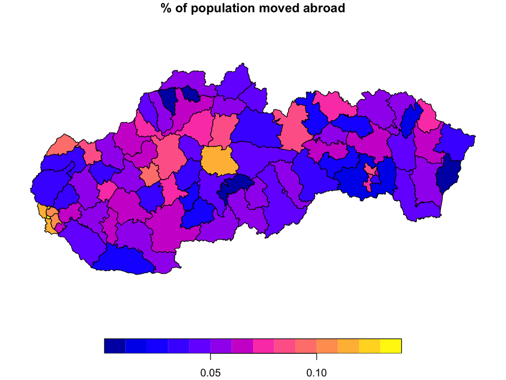

## Example: migration in Slovakia

Plotting side-by-side using the default method is possible, but has limitations such as not supporting legends. `tmap` package can handle those very well.

`tmap` allows integration with Open Street Map data and interactive maps on top of regular plotting. What we show here is only scratching the surface, for more examples, please visit the [tmap’s github page](https://github.com/mtennekes/tmap).

```r
install.packages('tmap')
```

```r
library(tmap)
```

## Example: migration in Slovakia

```r
pop.migration.sf.tall <- pop.migration.district.sf %>%
  tidyr::gather("type", "percent", c("outflow_abroad_percent", "outflow_sk_percent",
                                     "inflow_abroad_percent", "inflow_sk_percent")) %>%
  dplyr::mutate(type = gsub("_", " ", gsub("(.+)\\_percent", "\\1", type)))

sk.migration <- pop.migration.sf.tall %>%
  dplyr::filter(grepl('.*sk', type))

tm_shape(sk.migration) +
  tm_fill(col = "percent", style = "cont", title="% of population") +
  tm_style('gray', title = 'Migration within Slovakia') +
  tm_facets('type')
```

Exercise: do the same for migration to/out of Slovakia.

## Example: migration in Slovakia

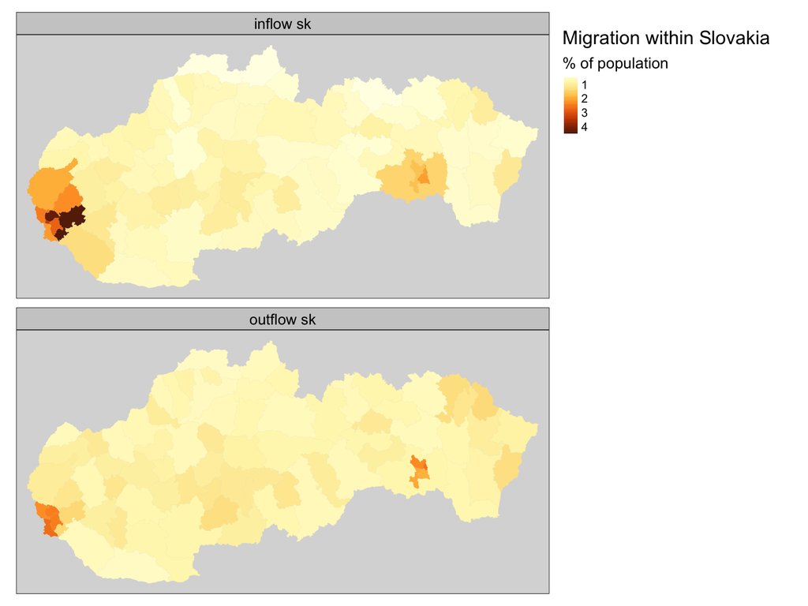

## Case study: respiratory diseases

1. Download the dataset from the official statistics portal
2. Plot the rate of deaths due to respiratory diseases.
3. Is there spatial correlation?

## Case study: respiratory diseases

```r
death.causes.df <- read_excel(file.path(getwd(), 'data', "raw", "deaths_causes.xlsx"), skip=7, col_names=FALSE)
colnames(death.causes.df) <- c('district', 'group', 'type', 'y2014', 'y2015', 'y2016', 'y2017', 'y2018')

# sum over the years, merge with population counts and group by disease group
respiratory.causes.df <- death.causes.df %>%
  dplyr::mutate(district = gsub("^District of (.+)$", "\\1", district)) %>%
  dplyr::mutate(counts_5year = (y2014 + y2015 + y2016 + y2017 + y2018) / 5) %>%
  dplyr::group_by(district, group) %>%
  dplyr::summarise(death_count = sum(counts_5year)) %>%
  dplyr::filter(group == 'X Diseases of the respiratory system') %>%
  dplyr::full_join(population.district.df, by = 'district') %>%
  dplyr::mutate(death_rate = 100 * (death_count / population)) %>%
  dplyr::mutate(district_ascii = stri_trans_general(str = district, id = "Latin-ASCII"))

# merge with the map
respiratory.causes.sf <- mapa.okres.sf %>%
  dplyr::mutate(district_ascii = stri_trans_general(str = okres, id = "Latin-ASCII")) %>%
  dplyr::left_join(respiratory.causes.df, by = "district_ascii")
```

## Case study: respiratory diseases

For a change, we will use `ggplot`:

```r
library(ggplot2)  # Load the ggplot library
library(viridis)  # Load the library for a nice colour palette
ggplot(respiratory.causes.sf) +
  geom_sf(aes(fill = death_rate)) +
  scale_fill_viridis("Death rate") +
  ggtitle("Deaths due to respiratory diseases") +
  theme_bw()
```

## Case study: respiratory diseases

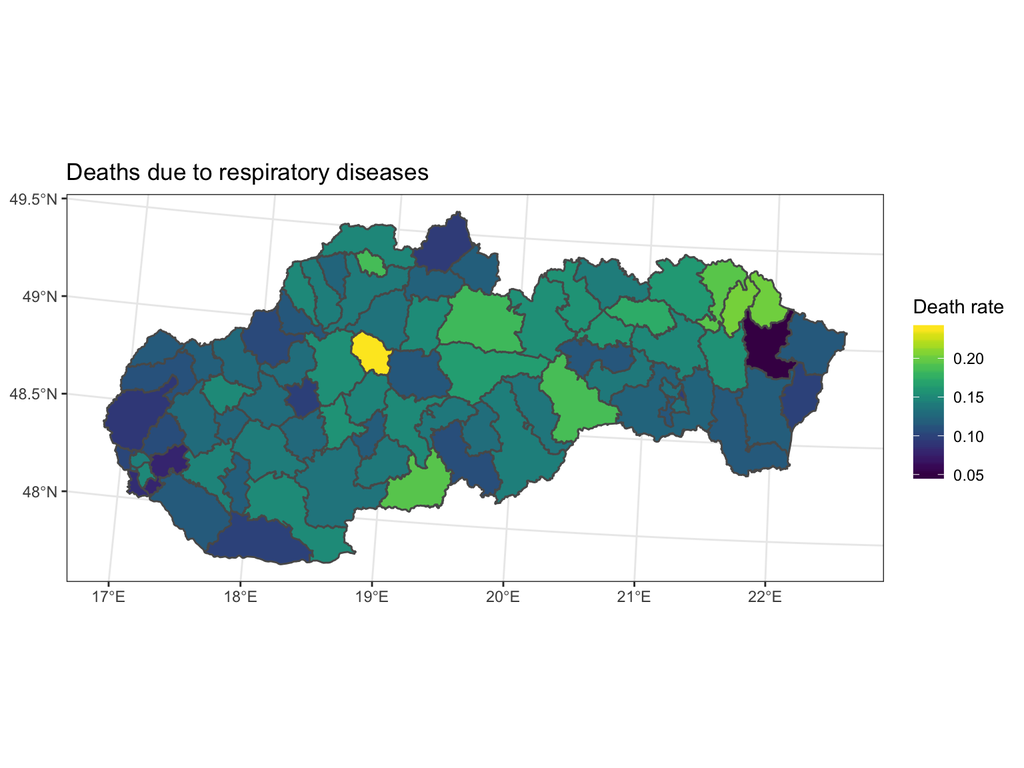

## Case study: respiratory diseases

- The plot suggests that districts next to each other often have very similar rate (btw. the hotspot is Turčianske Teplice).
- A common test for the presence of spatial autocorrelation in spatial statistics is so called *Moran’s I test*.
- A value very close to zero means that there is no spatial correlation present.

$$\begin{equation}
I=\frac{m \sum_{i=1}^{m} \sum_{j=1}^{m} w_{i j}\left(Z_{i}-\overline{Z}\right)\left(Z_{j}-\overline{Z}\right)}{\left(\sum_{i=1}^{m} \sum_{j=1}^{m} w_{i j}\right)\left(\sum_{i=1}^{m}\left(Z_{i}-\overline{Z}\right)^{2}\right)}
\end{equation}$$

## Case study: respiratory diseases

```r
library(spatstat)
library(sp)
library(spdep)

death.rates <- unlist(st_drop_geometry(respiratory.causes.sf['death_rate']))
nb.list <- poly2nb(pl = respiratory.causes.sf, snap = 1)
nb.weights <- nb2listw(nb.list)
spdep::moran.test(death.rates, nb.weights)
```

```
##
##  Moran I test under randomisation
##
## data:  death.rates
## weights: nb.weights
##
## Moran I statistic standard deviate = 2.6527, p-value = 0.003993
## alternative hypothesis: greater
## sample estimates:
## Moran I statistic       Expectation          Variance
##       0.177311258      -0.012820513       0.005137317
```

## Case study: respiratory diseases

- The value of Moran’s I statistic is 0.177 which is significantly above 0. The p-value is 0.003993.
- This suggests that the differences in the death rates are not only due to chance. This gives us indication to explore further and find explanatory variables that would explain the differences.
- **Challenge exercise:** take some explanatory variable (e.g. altitude, level of pollution), fit a simple linear model, and check the spatial autocorrelation of the residuals. Hopefully, adding explanatory variables reduces it.
- Often, we are not able to observe the relevant covariates. To account for this unexplained variation, a latent component is often introduced. Often it is a Gaussian random field. When the field is assumed to be Markovian, these can be fit efficiently. This is beyond the scope of the course, but models to watch out for are: CAR Models, BYM Models (refinement of CAR), log-Gaussian Cox process (for count data).

## Case study: elections 2019

Next, we look at presidential elections in Slovakia from 2019.

1. Download the raw dataset of the results from [here](http://volby.statistics.sk/prez/prez2019/sk/download.html).
2. Load the results, merge it with the geography you are interested in (obec, kraj)
3. Plot the results, including interactive maps.

## Case study: elections 2019

Load the data:

```r
library(readxl)
results.obec.file.path <- file.path(getwd(), 'data', "raw",
                                    "PRE_2019_KOLO1_xlsx",
                                    "PRE_2019_KOLO1_tab03e.xlsx")
results.obec <- read_excel(results.obec.file.path)
results.obec <- results.obec[-(1:4), ]
names(results.obec) <- c('kraj_id', 'kraj', 'uzemny_obvod_id', 'uzemny_obvod',
                         'okres_id', 'okres', 'obec_id', 'obec',
                         'candidate_id', 'candidate_fname', 'candidate_sname',
                         'platne_hlasy_count', 'platne_hlasy_percent',
                         'pullouts')
results.obec <- results.obec %>%
  dplyr::mutate_at(c("platne_hlasy_count", "platne_hlasy_percent"), as.numeric)
```

## Case study: elections 2019

Join the data with the map:

```r
results.obec.sf <- mapa.obec.sf %>%
  dplyr::select(obec_id) %>%
  dplyr::mutate(obec_id = as.character(obec_id)) %>%
  dplyr::full_join(results.obec, by = c("obec_id" = "obec_id")) %>%
  dplyr::mutate(name = paste(candidate_fname, candidate_sname, sep = " "))
```

## Case study: elections 2019

Since we are working with ‘obec’ level, we focus only on one ‘kraj’ region, and we only compare top 4 candidates in that region.

```r
zilinsky.kraj.results.sf <- results.obec.sf %>%
  dplyr::filter(kraj_id == 5)  # zilinsky kraj

# select top 4 candidates in Zilinsky kraj
zilinsky.kraj.top.candidates  <- zilinsky.kraj.results.sf %>%
  dplyr::group_by(name) %>%
  dplyr::summarise(vote_total = sum(platne_hlasy_count)) %>%
  dplyr::arrange(vote_total) %>%
  dplyr::top_n(4, vote_total) %>%
  dplyr::pull(name)

# filter out only the 4 candidates
zilinsky.kraj.results.top.candidates.sf <- zilinsky.kraj.results.sf %>%
  dplyr::filter(name %in% zilinsky.kraj.top.candidates)
```

## Case study: elections 2019

```r
tmap_mode("plot")
tm_shape(zilinsky.kraj.results.top.candidates.sf) +
  tm_fill(col = "platne_hlasy_percent", style = "cont", title="Podiel hlasov %") +
  tm_style('gray', title = 'Žilinsky kraj') +
  tm_facets('name')
```

## Case study: elections 2019

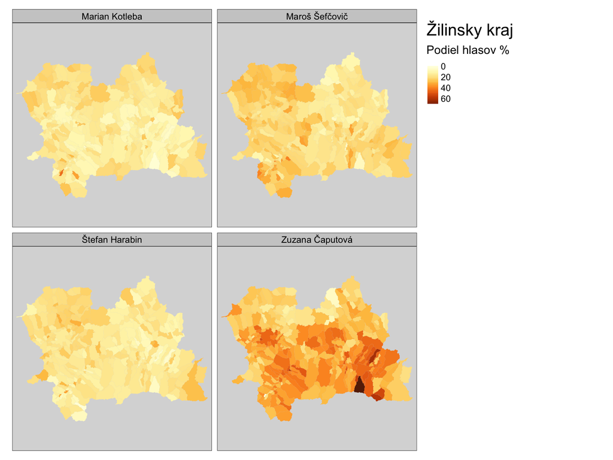

## Case study: elections 2019

As we can see this visualisation is not ideal, so we go for an interactive map where we can zoom in/out as we please.

```r
library(tidyr)

zilinsky.kraj.results.top.2.sf <- zilinsky.kraj.results.top.candidates.sf %>%
  dplyr::filter(name %in% c('Maroš Šefčovič', 'Zuzana Čaputová'))

zilinsky.results.wide.sf <- zilinsky.kraj.results.top.2.sf %>%
  dplyr::select(name, platne_hlasy_percent, obec) %>%
  tidyr::spread(name, platne_hlasy_percent)

tmap_mode("view")
tm <- tm_shape(zilinsky.results.wide.sf) +
  tm_polygons(c('Maroš Šefčovič', 'Zuzana Čaputová')) +
  tm_facets(sync = TRUE, ncol = 2) +
  tm_layout(legend.text.size = 0.4)
tm
```

## Case study: elections 2019

[figure not shown]